# HW8_Reinmann

Relika Reinmann

2022-12-12

# Analysis of Master students

## Introduction and aim of the analysis

A dataset from the website on Estonian statistics was downloaded. The dataset showcases the number of admitted students across different specialties and is recorded for Year 2021. The numbers of admitted students are presented for *Study programme group*, *Level of study*, and *Mother tongue*.

The aim of the analysis is to understand whether the mother tongue plays a role in admission of students to the Master’s level of studies with the focus on Russian and Estonian languages.

### EDA of the dataset

The whole dataset is composed of 108 objects of 6 variables, the data types of the variables level of study, study program, mother tongue is character, the number of students is integer. There are no NA values but for some study programme groups there have been 0 admissions. As initial observation, there are for both languages courses where 0 students have been admitted. Maximum number of admission for Russians is 85, whereas for Estonians it’s 531. On average 104 students of Estonian language have been admitted, and for Russian students it’s 16. Total number for Estonian speaking students is 2804 and for Russian speaking students 438.

```
##  Level.of.study     Study.programme.group    Estonian        Russian
##  Length:27          Length:27             Min.   :  0.0   Min.   : 0.00
##  Class :character   Class :character      1st Qu.: 28.0   1st Qu.: 1.50
##  Mode  :character   Mode  :character      Median : 53.0   Median : 7.00
##                                           Mean   :103.9   Mean   :16.22
##                                           3rd Qu.:113.5   3rd Qu.:18.50
##                                           Max.   :531.0   Max.   :85.00
##  Other.mother.tongue Mother.tongue.unknown
##  Min.   :  0.00      Min.   : 0.00
##  1st Qu.:  0.00      1st Qu.: 0.00
##  Median :  9.00      Median : 4.00
##  Mean   : 19.48      Mean   :14.93
##  3rd Qu.: 19.50      3rd Qu.:18.00
##  Max.   :103.00      Max.   :72.00
```

### Research question

In order to conduct the analysis of the dataset, a research question has been raised:

RQ1 Is there a difference in admission amount in master studies between Estonian and Russian speaking students?

## Hypothesis testing

In order to test the hypothesis, a zero and alternative hypothesis have been states as follows:

H0 The Estonian and Russian speaking students are continuing in master studies in similar numbers

H1 The Estonians and Russian speaking students are not continuing in master studies in similar numbers

### Collected data and sample size

Data is collected regarding 27 different Master’s degree courses and the number of admitted students for each course.

### Statistical test and assumptions

Assumptions are that: data independence -> randomly selected participants Variable normality

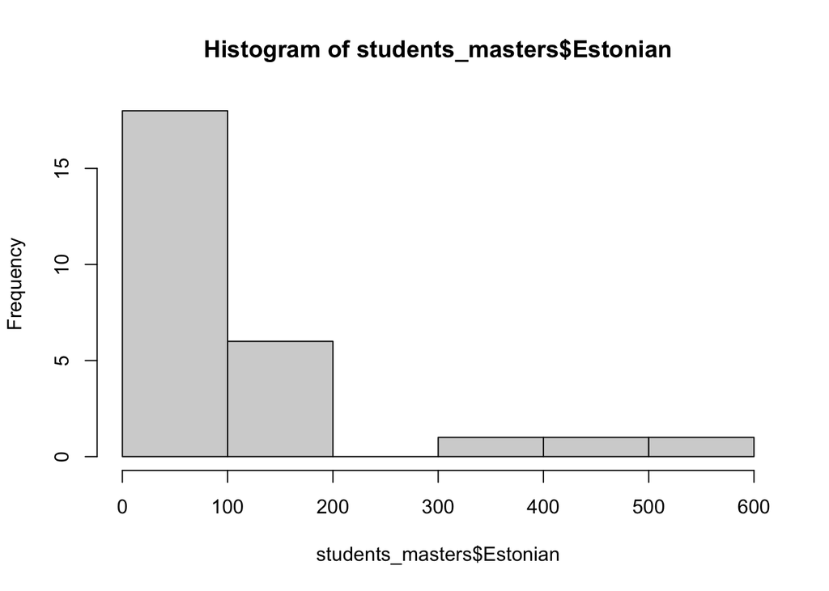

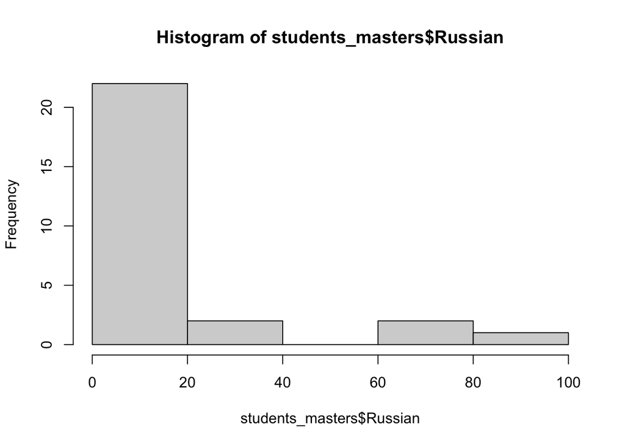

```
##
##  Two Sample t-test
##
## data:  Estonian_students and Russian_students
## t = 3.329, df = 52, p-value = 0.001607
## alternative hypothesis: true difference in means is not equal to 0
## 95 percent confidence interval:
##   34.80823 140.45103
## sample estimates:
## mean of x mean of y
## 103.85185  16.22222
```

## Results

There was a significant difference on language and admission to Master’s degree between Estonians (M = 103.851, SD = 134.597) and Russians (M = 16.222, SD = 24.334); t(52)= 3.329, p= 0.001607. Therefore the H0 is rejected.